# Week 11: Linear Regression

# Create a linear regression model that uses multiple predictor variables to predict Sale Price (feel free to derive new predictors from existing ones). Explain why you think each of these variables may add explanatory value to the model.

```r
# Derive new predictors
housing_df <- housing_df %>%
  mutate(
    total_rooms = bedrooms + bathrooms,
    space_per_story = ifelse(stories == 0, NA, area / stories) # Avoid division by zero
  )

# Fit multiple linear regression model, this time only using the total rooms and space per story
multi_lm_model <- lm(price_usd_100k ~ total_rooms + space_per_story, data = housing_df)

# Using this for later
all_variables_lm_model <- lm(price_usd_100k ~ total_rooms + space_per_story+ area+bedrooms+bathrooms+stories, data = housing_df)

# Explain variables
cat(
  "New Predictors:\n",
  "- Total Rooms: Combines bedrooms and bathrooms for overall living capacity.\n",
  "- Space per Story: Multi story homes might be weighted differently given the average size.\n"
)
```

```
## New Predictors:
##  - Total Rooms: Combines bedrooms and bathrooms for overall living capacity.
##  - Space per Story: Multi story homes might be weighted differently given the average size.
```

Get a summary of this GLM and explain your results.

```r
# Display model summary
summary(multi_lm_model)
```

```
##
## Call:
## lm(formula = price_usd_100k ~ total_rooms + space_per_story,
##     data = housing_df)
##
## Residuals:
##     Min      1Q  Median      3Q     Max
## -42.425 -10.443  -1.480   7.546  69.565
##
## Coefficients:
##                   Estimate Std. Error t value Pr(>|t|)
## (Intercept)     -1.6817646  3.2735021  -0.514    0.608
## total_rooms     10.0916376  0.6596388  15.299  < 2e-16 ***
## space_per_story  0.0018463  0.0003044   6.065 2.48e-09 ***
## ---
## Signif. codes:  0 '***' 0.001 '**' 0.01 '*' 0.05 '.' 0.1 ' ' 1
##
## Residual standard error: 15.58 on 542 degrees of freedom
## Multiple R-squared:  0.3089, Adjusted R-squared:  0.3063
## F-statistic: 121.1 on 2 and 542 DF,  p-value: < 2.2e-16
```

```r
# Get values
r_squared <- summary(multi_lm_model)$r.squared
adj_r_squared <- summary(multi_lm_model)$adj.r.squared
rmse <- sqrt(mean(multi_lm_model$residuals^2))
mse <- mean(multi_lm_model$residuals^2)
# Print results
cat("R-squared:", r_squared, "\n") #  0.3088521
```

```
## R-squared: 0.3088521
```

```r
cat("Adjusted R-squared:", adj_r_squared, "\n") # 0.3063018
```

```
## Adjusted R-squared: 0.3063018
```

```r
cat("RMSE:", rmse, "\n") # 15.53568
```

```
## RMSE: 15.53568
```

```r
cat("MSE:", mse, "\n") #  241.3575
```

```
## MSE: 241.3575
```

```r
cat("R-squared -", round(r_squared, 3), ": About", round(r_squared * 100, 1), "% of the variation in sale price is explained by the model.\n")
```

```
## R-squared - 0.309 : About 30.9 % of the variation in sale price is explained by the model.
```

```r
cat("Adjusted R-squared -", round(adj_r_squared, 3), ": Adjusts R-squared for the number of predictors; still shows a moderate fit.\n")
```

```
## Adjusted R-squared - 0.306 : Adjusts R-squared for the number of predictors; still shows a moderate fit.
```

```r
cat("RMSE -", round(rmse, 2), ": On average, predictions are off by about $", round(rmse * 100000, 0), ".\n")
```

```
## RMSE - 15.54 : On average, predictions are off by about $ 1553568 .
```

```r
cat("MSE -", round(mse, 2), ": This is the average squared error; lower values indicate better model performance.\n")
```

```
## MSE - 241.36 : This is the average squared error; lower values indicate better model performance.
```

```r
# Do the same, but for all variables. Note! This is only to add a experiment with a third model, even though the assignment only calls for 2. For the major of tasks, this will model will be omitted, but we'll use it for the final ANOVA.
all_r_squared <- summary(all_variables_lm_model)$r.squared
all_adj_r_squared <- summary(all_variables_lm_model)$adj.r.squared
all_rmse <- sqrt(mean(all_variables_lm_model$residuals^2))
all_mse <- mean(all_variables_lm_model$residuals^2)
```

Get the residuals of your second model (you can use ‘resid’ or ‘residuals’ functions) and plot them. What does the plot tell you about your predictions?

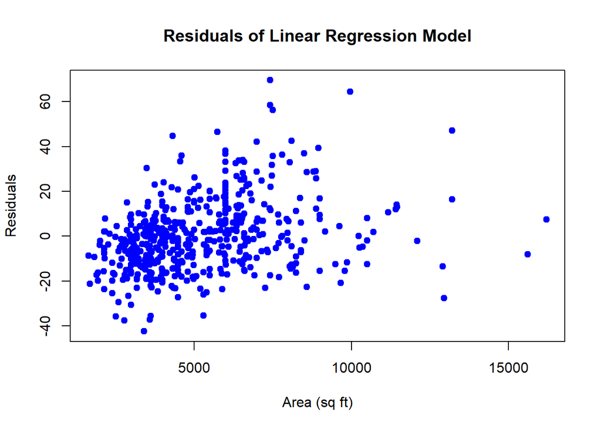

```r
# Get residuals
residuals_lm_multi <- resid(multi_lm_model)
# Plot residuals
plot(
  housing_df$area, residuals_lm_multi,
  main = "Residuals of Linear Regression Model",
  xlab = "Area (sq ft)", ylab = "Residuals",
  pch = 19, col = "blue"
)
```